# Assignment 1

## *How can we control the increasing number of accidents in New York?*

```python
import json
import requests
from bs4 import BeautifulSoup
import pandas as pd
import matplotlib.pyplot as plt
import seaborn as sns
import numpy
```

## Introduction

**Business Context.** The city of New York has seen a rise in the number of accidents on the roads in the city. They would like to know if the number of accidents have increased in the last few weeks. For all the reported accidents, they have collected details for each accident and have been maintaining records for the past year and a half (from January 2018 to August 2019).

The city has contracted you to build visualizations that would help them identify patterns in accidents, which would help them take preventive actions to reduce the number of accidents in the future. They have certain parameters like borough, time of day, reason for accident, etc. Which they care about and which they would like to get specific information on.

**Business Problem.** Your task is to format the given data and provide visualizations that would answer the specific questions the client has, which are mentioned below.

**Analytical Context.** You are given a CSV file (stored in the already created `data` folder) containing details about each accident like date, time, location of the accident, reason for the accident, types of vehicles involved, injury and death count, etc. The delimiter in the given CSV file is `;` instead of the default `,`. You will be performing the following tasks on the data:

1. Extract additional borough data stored in a JSON file
2. Read, transform, and prepare data for visualization
3. Perform analytics and construct visualizations of the data to identify patterns in the dataset

The client has a specific set of questions they would like to get answers to. You will need to provide visualizations to accompany these:

1. How have the number of accidents fluctuated over the past year and a half? Have they increased over the time?
2. For any particular day, during which hours are accidents most likely to occur?
3. Are there more accidents on weekdays than weekends?
4. What are the accidents count-to-area ratio per borough? Which boroughs have disproportionately large numbers of accidents for their size?
5. For each borough, during which hours are accidents most likely to occur?
6. What are the top 5 causes of accidents in the city?
7. What types of vehicles are most involved in accidents per borough?
8. What types of vehicles are most involved in deaths?

## Fetching the relevant data

The client has requested analysis of the accidents-to-area ratio for boroughs. Borough data is stored in a JSON file in the `data` folder.

### Question :

Use the function `json.load()` to load the file `borough_data.json` as a dictionary.

```python
import json

# Open and load the JSON file
with open("data/borough_data.json", "r") as f:
    borough_data = json.load(f)

# borough_data is now a Python dictionary
print(type(borough_data))
print(borough_data)
```

[output not shown]

**Answer.**

### Question :

Similarly, use the pandas function `read_csv()` to load the file `accidents.csv` as a DataFrame. Name this DataFrame `df`.

**Answer.**

```python
import pandas as pd

df = pd.read_csv("data/accidents.csv", sep=None, engine="python")

print(type(df))
print(df.head())
```

```
<class 'pandas.core.frame.DataFrame'>
         DATE   TIME   BOROUGH  ZIP CODE   LATITUDE  LONGITUDE  \
0  09/26/2018  12:12     BRONX   10454.0  40.808987 -73.911316
1  09/25/2018  16:30  BROOKLYN   11236.0  40.636005 -73.912510
2  08/22/2019  19:30    QUEENS   11101.0  40.755490 -73.939530
3  09/23/2018  13:10    QUEENS   11367.0        NaN        NaN
4  08/20/2019  22:40     BRONX   10468.0  40.868336 -73.901270

                     ON STREET NAME  NUMBER OF PEDESTRIANS INJURED  \
0                               NaN                              0
1  FLATLANDS AVENUE                                              1
2                               NaN                              0
3  MAIN STREET                                                   0
4                               NaN                              0

```

[output cut: 36 more lines]

## Overview of the data

Let's go through the columns present in the dataframe:

```python
df.columns
```

```
Index(['DATE', 'TIME', 'BOROUGH', 'ZIP CODE', 'LATITUDE', 'LONGITUDE',
       'ON STREET NAME', 'NUMBER OF PEDESTRIANS INJURED',
       'NUMBER OF PEDESTRIANS KILLED', 'NUMBER OF CYCLIST INJURED',
       'NUMBER OF CYCLIST KILLED', 'NUMBER OF MOTORIST INJURED',
       'NUMBER OF MOTORIST KILLED', 'CONTRIBUTING FACTOR VEHICLE 1',
       'CONTRIBUTING FACTOR VEHICLE 2', 'CONTRIBUTING FACTOR VEHICLE 3',
       'CONTRIBUTING FACTOR VEHICLE 4', 'CONTRIBUTING FACTOR VEHICLE 5',
       'COLLISION_ID', 'VEHICLE TYPE CODE 1', 'VEHICLE TYPE CODE 2',
       'VEHICLE TYPE CODE 3', 'VEHICLE TYPE CODE 4', 'VEHICLE TYPE CODE 5'],
      dtype='object')
```

```python
df.head()
```

|  | DATE | TIME | BOROUGH | ZIP CODE | LATITUDE | LONGITUDE | ON STREET NAME | NUMBER OF PEDESTRIANS INJURED | NUMBER OF PEDESTRIANS KILLED | NUMBER OF CYCLIST INJURED | ... | CONTRIBUTING FACTOR VEHICLE 2 | CONTRIBUTING FACTOR VEHICLE 3 | CONTRIBUTING FACTOR VEHICLE 4 | CONTRIBUTING FACTOR VEHICLE 5 | COLLISION_ID | VEHICLE TYPE CODE 1 | VEHICLE TYPE CODE 2 | VEHICLE TYPE CODE 3 | VEHICLE TYPE CODE 4 | VEHICLE TYPE CODE 5 |
| --- | --- | --- | --- | --- | --- | --- | --- | --- | --- | --- | --- | --- | --- | --- | --- | --- | --- | --- | --- | --- | --- |
| 0 | 09/26/2018 | 12:12 | BRONX | 10454.0 | 40.808987 | -73.911316 | NaN | 0 | 0 | 0 | ... | NaN | NaN | NaN | NaN | 3988123 | Sedan | NaN | NaN | NaN | NaN |
| 1 | 09/25/2018 | 16:30 | BROOKLYN | 11236.0 | 40.636005 | -73.912510 | FLATLANDS AVENUE | 1 | 0 | 0 | ... | NaN | NaN | NaN | NaN | 3987962 | Sedan | NaN | NaN | NaN | NaN |
| 2 | 08/22/2019 | 19:30 | QUEENS | 11101.0 | 40.755490 | -73.939530 | NaN | 0 | 0 | 0 | ... | NaN | NaN | NaN | NaN | 4193132 | Sedan | NaN | NaN | NaN | NaN |
| 3 | 09/23/2018 | 13:10 | QUEENS | 11367.0 | NaN | NaN | MAIN STREET | 0 | 0 | 1 | ... | Unspecified | NaN | NaN | NaN | 3985962 | Bike | Station Wagon/Sport Utility Vehicle | NaN | NaN | NaN |
| 4 | 08/20/2019 | 22:40 | BRONX | 10468.0 | 40.868336 | -73.901270 | NaN | 0 | 0 | 0 | ... | Unspecified | NaN | NaN | NaN | 4192111 | Sedan | Sedan | NaN | NaN | NaN |

5 rows × 24 columns

We have the following columns

1. **BOROUGH**: The borough in which the accident occured
2. **COLLISION_ID**: A unique identifier for this collision
3. **CONTRIBUTING FACTOR VEHICLE (1, 2, 3, 4, 5)**: Reasons for the accident
4. **CROSS STREET NAME**: Nearest cross street to the place of accidents
5. **DATE**: Date of the accident
6. **TIME**: Time of accident
7. **LATITUDE**: Latitude of the accident
8. **LONGITUDE**: Longitude of the accident
9. **NUMBER OF (CYCLISTS, MOTORISTS, PEDESTRIANS) INJURED**: Category wise injury
10. **NUMBER OF (CYCLISTS, MOTORISTS, PEDESTRIANS) KILLED**: Category wise death
11. **ON STREET NAME**: Street where the accident occured
12. **VEHICLE TYPE CODE (1, 2, 3, 4, 5)**: Types of vehicles involved in the accident
13. **ZIP CODE**: zip code of the accident location

### Exercise 1 :

Since 2014, New York City has been implementing a road safety plan named [Vision Zero](https://www1.nyc.gov/content/visionzero/pages/). It aims to reduce the number of traffic deaths to *zero* by the end of 2024. The plan is creating new and enhancing current safety measures, some of these include:

- [ ] Automated pedestrian detection
- [x] Road safety audits at high risk locations
- [x] Expansion in the cycle track network
- [ ] Targeted education and awareness initiatives
- [x] Creation of pedestrian refuge islands
- [x] Launch Integrated Data-Driven Speed Reducer Program (speed humps & speed cushions)

Which of these initiatives could directly benefit from an analysis of the data provided? Check all that apply.

**Note:** You can create check marks by double-clicking this cell and adding an `[x]` in the corresponding lines.

**Answer.**

Let's go ahead and answer each of the client's questions.

## Answering the client's questions

### Exercise 2 :

Group the available data on a monthly basis and generate a line plot of accidents over time. Has the number of accidents increased over the past year and a half?

**Hint**: You may find the pandas functions `to_datetime()` and `dt.to_period()` useful.

**Answer.**

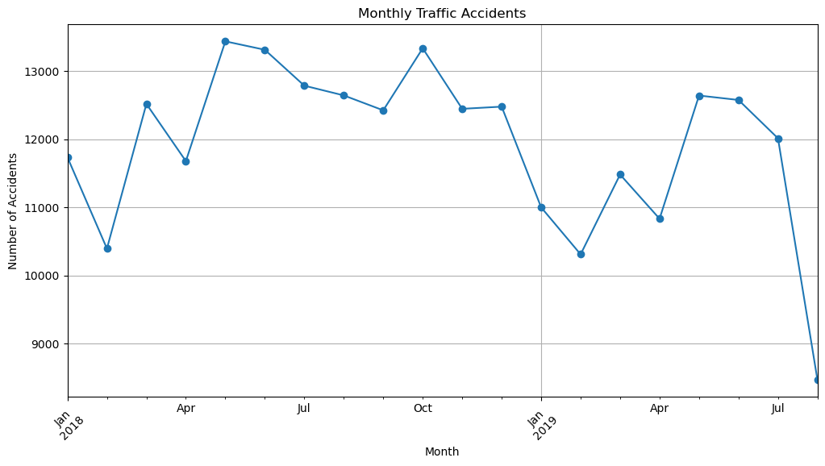

```python
df["DATE"] = pd.to_datetime(df["DATE"], format="%m/%d/%Y")
df["MONTH"] = df["DATE"].dt.month
df["MONTH_PERIOD"] = df["DATE"].dt.to_period("M")
monthly_accidents = df.groupby("MONTH_PERIOD").size()
plt.figure(figsize=(12,6))
monthly_accidents.plot(kind="line", marker="o")
plt.title("Monthly Traffic Accidents")
plt.xlabel("Month")
plt.ylabel("Number of Accidents")
plt.xticks(rotation=45)
plt.grid(True)
plt.show()
```

### Exercise 3 :

From the plot above, which months seem to have the least number of accidents? What do you think are the reasons behind this?

**Answer.** Feb 2018, Feb 2019, Apr 2019 and Aug 2019

Fewer commuters or city residents (summer vacations, February short month).

School breaks reduce pedestrian/vehicle interactions.

Milder weather reduces weather-related accidents.

Traffic regulations and Vision Zero initiatives improve overall safety

### Exercise 4 :

How does the number of accidents vary throughout a single day? Create a new column `HOUR` based on the data from the `TIME` column, then plot a bar graph of the distribution per hour throughout the day.

**Hint:** You may find the function `dt.hour` useful.

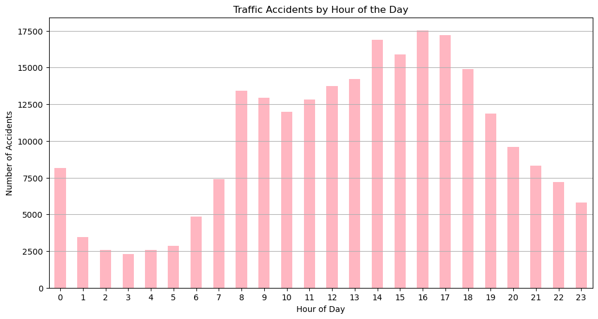

```python
df["TIME"] = pd.to_datetime(df["TIME"], format="%H:%M")
df["HOUR"] = df["TIME"].dt.hour
hourly_accidents = df.groupby("HOUR").size()
plt.figure(figsize=(12,6))
hourly_accidents.plot(kind="bar", color="lightpink")
plt.title("Traffic Accidents by Hour of the Day")
plt.xlabel("Hour of Day")
plt.ylabel("Number of Accidents")
plt.xticks(rotation=0)
plt.grid(axis="y")
plt.show()
```

**Answer.**

From this, we see that more accidents occur in the afternoon (2 - 6 PM) than at other times of day.

### Exercise 5 :

In the above question we have aggregated the number accidents per hour disregarding the date and place of ocurrence. Which criticism would you give to this approach?

**Answer.** Aggregating by hour gives a general trend but it diregards the important details of when and where the accidents happen, which limits how actionable the analysis is.

### Exercise 6 :

How does the number of accidents vary throughout a single week? Plot a bar graph based on the accidents count by day of the week.

**Hint:** You may find the function `dt.weekday` useful.

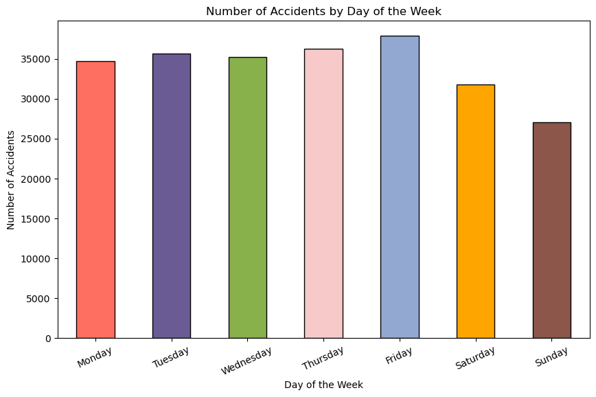

[output not shown]

```python
df["DATE"] = pd.to_datetime(df["DATE"], format="%m/%d/%Y")
df["WEEKDAY"] = df["DATE"].dt.weekday
weekly_accidents = df["WEEKDAY"].value_counts().sort_index()
weekday_names = {0: "Monday", 1: "Tuesday", 2: "Wednesday",
                 3: "Thursday", 4: "Friday", 5: "Saturday", 6: "Sunday"}

weekly_accidents.index = weekly_accidents.index.map(weekday_names)
colors = ["#FF6F61", "#6B5B95", "#88B04B", "#F7CAC9", "#92A8D1", "#FFA500", "#8C564B"]

plt.figure(figsize=(10,6))
weekly_accidents.plot(kind="bar", color=colors, edgecolor="black")
plt.title("Number of Accidents by Day of the Week")
plt.xlabel("Day of the Week")
plt.ylabel("Number of Accidents")
plt.xticks(rotation=25)
plt.show()
print("The number of accidents shows an increase from Monday to Friday. It is maximum on Friday. It then shows a decreases on weekends with Sunday having the least number of accidents.")
```

**Answer.**

### Exercise 7 :

Plot a bar graph of the total number of accidents in each borough, as well as one of the accidents per square mile per borough. What can you conclude?

**Hint:** You may want to update some of the keys in the borough dictionary to match the names in the dataframe.

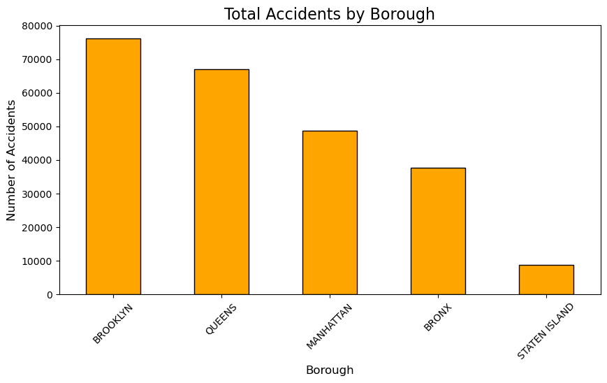

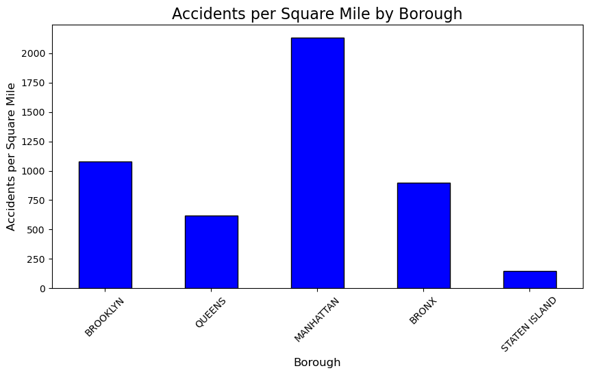

```
Observation: In the 'Number of Accidents by Borough' graph, Brooklyn has the highest accidents and Staten Island the lowest, while in the 'Accidents per Square Mile' graph, Manhattan is the highest due to its small area.
```

```python
total_accidents = df["BOROUGH"].value_counts()
plt.figure(figsize=(10,5))
total_accidents.plot(kind="bar", color="orange", edgecolor="black")
plt.title("Total Accidents by Borough", fontsize=16)
plt.xlabel("Borough", fontsize=12)
plt.ylabel("Number of Accidents", fontsize=12)
plt.xticks(rotation=45)
plt.show()

borough_area = {"BRONX" : 42.1, "BROOKLYN" : 70.82, "MANHATTAN": 22.83, "QUEENS": 108.53, "STATEN ISLAND":58.37}

accidents_per_sq_mile = total_accidents.copy()
for borough in accidents_per_sq_mile.index:
    if borough in borough_area:
        accidents_per_sq_mile[borough] = accidents_per_sq_mile[borough] / borough_area[borough]

plt.figure(figsize=(10,5))
accidents_per_sq_mile.plot(kind="bar", color="blue", edgecolor="black")
plt.title("Accidents per Square Mile by Borough", fontsize=16)
plt.xlabel("Borough", fontsize=12)
plt.ylabel("Accidents per Square Mile", fontsize=12)
plt.xticks(rotation=45)
plt.show()

print(f"Observation: In the 'Number of Accidents by Borough' graph, Brooklyn has the highest accidents and Staten Island the lowest, while in the 'Accidents per Square Mile' graph, Manhattan is the highest due to its small area.")
```

**Answer.**

### Exercise 8 :

Which hours have the most accidents for each borough? Plot a bar graph for each borough showing the number of accidents for each hour of the day.

**Hint:** You can use `sns.FacetGrid` to create a grid of plots with the hourly data of each borough.

**Answer.**

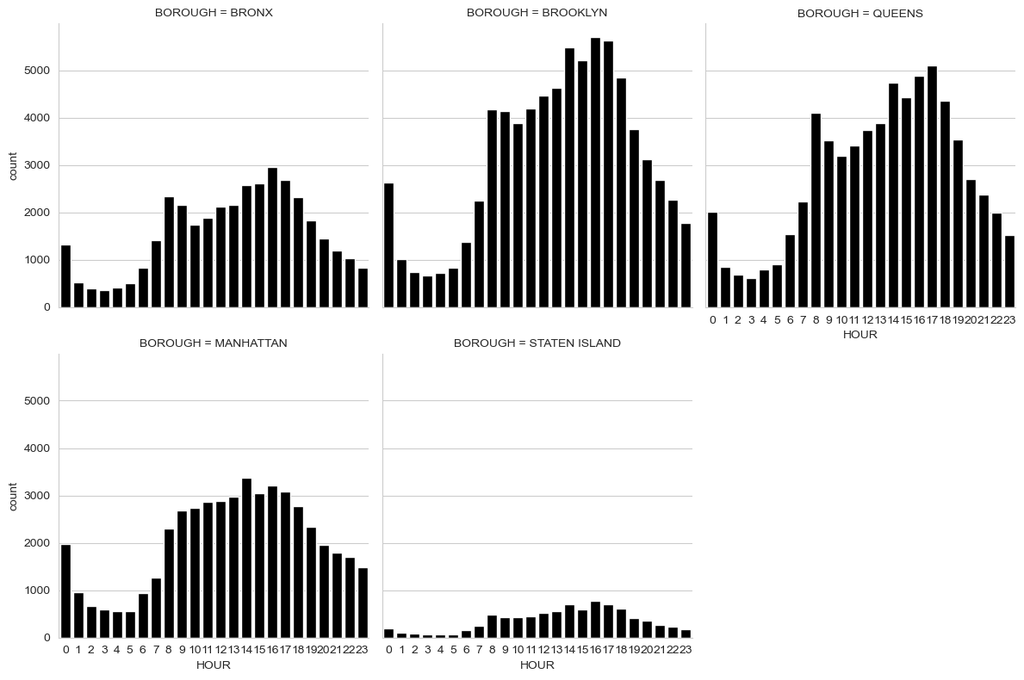

```python
sns.set_style("whitegrid")


g = sns.FacetGrid(df, col="BOROUGH", col_wrap=3, height=4)
g.map_dataframe(sns.countplot, x="HOUR", color="black", order=range(0,24))
```

**Is the number of accidents higher at different times in different boroughs? Should we concentrate at different times for each borough?**

We can see that in all the boroughs the accident count is highest from approximately 2 - 6PM. But in Manhattan and the Bronx, you can see that there is not as much of a relative increase during these hours as in Brooklyn or Queens. Additionally, Staten Island has the lowest overall number of accidents.

### Exercise 9 :

What factors cause the most accidents? Avoid double counting the contributing factors of a single accident.

**Hint:** One way of dealing with repetitions is to concatenate the corresponding columns while preserving their indexes, you can do that with the functions `pd.concat()` and `reset_index()`. Then, use an appropiate `group_by` to count the number of repetitions of contributed factors per accident.

```python
factor_cols = [
    "CONTRIBUTING FACTOR VEHICLE 1",
    "CONTRIBUTING FACTOR VEHICLE 2",
    "CONTRIBUTING FACTOR VEHICLE 3",
    "CONTRIBUTING FACTOR VEHICLE 4",
    "CONTRIBUTING FACTOR VEHICLE 5"
]


factors = pd.concat(
    [df[["COLLISION_ID", col]].rename(columns={col: "FACTOR"}) for col in factor_cols],
    axis=0
).reset_index(drop=True)

# Drop missing factors
factors = factors.dropna()

# Avoid double counting same factor in the same accident
factors = factors.drop_duplicates()

# Count most common factors
factor_counts = factors.groupby("FACTOR")["COLLISION_ID"].count().reset_index()
factor_counts = factor_counts.rename(columns={"COLLISION_ID": "ACCIDENT_COUNT"})

# Sort descending
factor_counts = factor_counts.sort_values(by="ACCIDENT_COUNT", ascending=False)

print(factor_counts.head(10))
```

```
                            FACTOR  ACCIDENT_COUNT
50                     Unspecified          190096
8   Driver Inattention/Distraction           61752
14   Failure to Yield Right-of-Way           19641
17           Following Too Closely           17293
4                 Backing Unsafely           14835
31             Passing Too Closely           12631
32  Passing or Lane Usage Improper           11808
27                 Other Vehicular            8860
48            Unsafe Lane Changing            6643
47              Turning Improperly            6626
```

**Answer.**

### Exercise 10 :

Which vehicle types are most involved in accidents per borough? Avoid double counting the type of vehicles present in a single accident.

**Hint:** You can apply a similar approach to the one used in the previous question.

```python
vehicle_cols = [
    "VEHICLE TYPE CODE 1",
    "VEHICLE TYPE CODE 2",
    "VEHICLE TYPE CODE 3",
    "VEHICLE TYPE CODE 4",
    "VEHICLE TYPE CODE 5"
]

# Step 2: Stack all vehicle columns into one "VEHICLE" column
vehicles = pd.concat(
    [df[["COLLISION_ID", "BOROUGH", col]].rename(columns={col: "VEHICLE"}) for col in vehicle_cols],
    axis=0
).reset_index(drop=True)

# Step 3: Clean
vehicles = vehicles.dropna()              # remove missing entries
vehicles = vehicles.drop_duplicates()     # avoid double counting same vehicle type per accident

# Step 4: Count vehicles per borough
vehicle_counts = (
    vehicles.groupby(["BOROUGH", "VEHICLE"])["COLLISION_ID"]
    .count()
    .reset_index()
    .rename(columns={"COLLISION_ID": "ACCIDENT_COUNT"})
)

# Step 5: Sort
vehicle_counts = vehicle_counts.sort_values(by=["BOROUGH", "ACCIDENT_COUNT"], ascending=[True, False])

print(vehicle_counts.head(20))   # show top 20 results
```

```
    BOROUGH                              VEHICLE  ACCIDENT_COUNT
181   BRONX                                Sedan           19652
185   BRONX  Station Wagon/Sport Utility Vehicle           15434
146   BRONX                    PASSENGER VEHICLE            4941
174   BRONX        SPORT UTILITY / STATION WAGON            3751
157   BRONX                        Pick-up Truck            1670
203   BRONX                                 Taxi            1623
30    BRONX                            Box Truck            1098
32    BRONX                                  Bus            1051
29    BRONX                                 Bike             687
210   BRONX                 Tractor Truck Diesel             570
188   BRONX                                 TAXI             435
147   BRONX                        PICK-UP TRUCK             423
237   BRONX                                  Van             302
25    BRONX                                   BU             293
130   BRONX                           Motorcycle             270
13    BRONX                            Ambulance             238
189   BRONX                                   TK             236
62    BRONX                                 Dump             147
53    BRONX                          Convertible             125
60    BRONX                                   DS             124
```

**Answer.**

### Exercise 11 :

In a 2018 [interview](https://www.nytimes.com/2019/01/01/nyregion/traffic-deaths-decrease-nyc.html) with The New York Times, New York's mayor de Blasio stated that *'Vision Zero is clearly working'*. That year, the number of deaths in traffic accidents in NYC dropped to a historical 202. Yet, as reported by [am New York Metro](https://www.amny.com/news/vision-zero-de-blasio-1-30707464/), the number of fatalities has increased by 30% in the first quarter of 2019 compared to the previous year and the number of pedestrians and cyclist injured has not seen any improvement.

How would you use the provided data to understand what went wrong in the first quarter of 2019?

> - [ ] Consider the accidents of the first quarter of 2019. Then, check for the most common causes of accidents where pedestrians and cyclists were involved. Give a recommendation based solely on this information.
> - [x] Create a pair of heatmaps of the accidents involving injured/killed pedestrians and cyclists in the first quarter of 2018 and 2019. Compare these two to see if there is any change in the concentration of accidents. In critical areas, study the type of factors involved in the accidents. Give a recommendation to visit these areas to study the problem further.
> - [ ] The provided data is insufficient to improve our understanding of the situation.
> - [ ] None of the above. I would do the following: *here your recommended answer*.

**Answer.**

### Exercise 12 :

Calculate the number of deaths caused by each type of vehicle. Plot a bar chart for the top 5 vehicles. Which vehicles are most often involved in deaths, and by how much more than the others?

**For example,** if two people died at an accident where 5 vehicles were involved: 4 are PASSENGER VEHICLE and 1 is a SPORT UTILITY/STATION WAGON. Then, we would add two deaths to each PASSENGER VEHICLE and SPORT UTILITY/STATION WAGON types.

**Hint:** You may want to create a new column with the total number of kills in the accident. For that you may find the function `.to_numpy()` useful. Then, proceed as the previous excercises to avoid double-counting the type of vehicles.

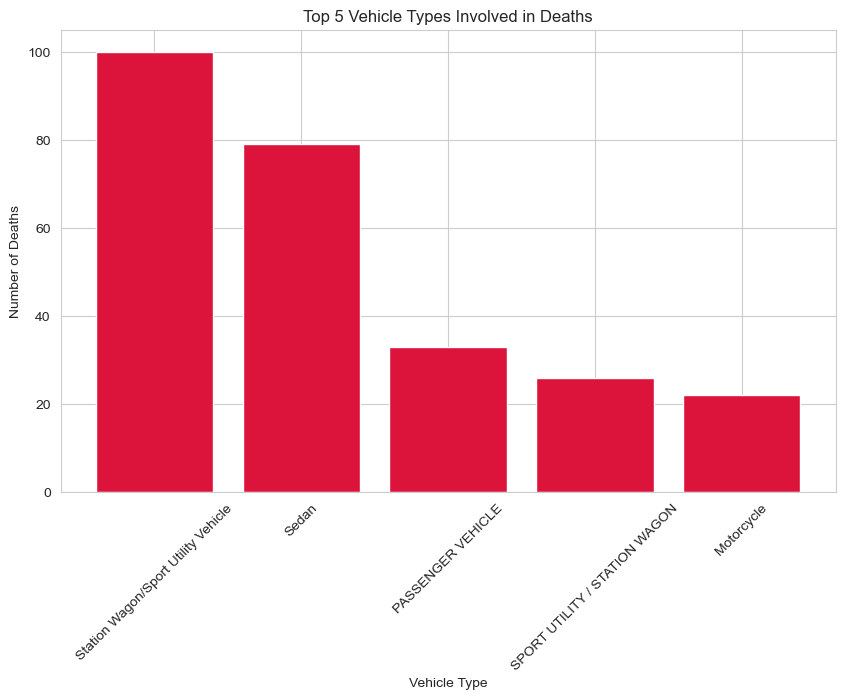

```
The most deadly vehicle type has 21 more deaths than the second most deadly.
```

```python
df["TOTAL_KILLS"] = df[["NUMBER OF PEDESTRIANS KILLED",
                        "NUMBER OF CYCLIST KILLED",
                        "NUMBER OF MOTORIST KILLED"]].sum(axis=1)

# Step 2: Vehicle columns
vehicle_cols = [
    "VEHICLE TYPE CODE 1",
    "VEHICLE TYPE CODE 2",
    "VEHICLE TYPE CODE 3",
    "VEHICLE TYPE CODE 4",
    "VEHICLE TYPE CODE 5"
]

# Step 3: Stack vehicle columns into one dataframe
vehicles = pd.concat(
    [df[["COLLISION_ID", "TOTAL_KILLS", col]].rename(columns={col: "VEHICLE"}) for col in vehicle_cols],
    axis=0
).reset_index(drop=True)

# Step 4: Remove missing vehicles
vehicles = vehicles.dropna()

# Step 5: Sum deaths per vehicle type
vehicle_deaths = vehicles.groupby("VEHICLE")["TOTAL_KILLS"].sum().reset_index()
vehicle_deaths = vehicle_deaths.sort_values(by="TOTAL_KILLS", ascending=False)

# Step 6: Plot top 5 vehicle types
top5 = vehicle_deaths.head(5)

plt.figure(figsize=(10,6))
plt.bar(top5["VEHICLE"], top5["TOTAL_KILLS"], color='crimson')
plt.xlabel("Vehicle Type")
plt.ylabel("Number of Deaths")
plt.title("Top 5 Vehicle Types Involved in Deaths")
plt.xticks(rotation=45)
plt.show()

# Step 7: Difference between top vehicle and second
top_count = top5["TOTAL_KILLS"].iloc[0]
second_count = top5["TOTAL_KILLS"].iloc[1]
difference = top_count - second_count
print(f"The most deadly vehicle type has {difference} more deaths than the second most deadly.")
```

**Answer.**